# Project: Investigate a Dataset - FBI Gun Data

- Introduction
- Data Wrangling
- Exploratory Data Analysis
- Conclusions

## Introduction

### Dataset Description

> This data set is a combination of data that comes from the FBI's National Instant Criminal Background Check System (NICS) and state level data from [census.gov](https://www.census.gov/). The NCIS is used by guns shopts to ensure their customers aren't ineligible to make a purchase. The NICS data consists of the following columns: month, state, permit, permit_recheck, handgun, long_gun, other, multiple, admin. There is also a column for handgun, long_gun, and other for each of the following: prepawn_, redemption_, returned_, private_sale_, return_to_seller_. Finally there is a rentals_ column for each handgun and long_gun. The Census data consists of the columns: fact, fact_note, and one for each state. The fact column explains what classification was being measured for that row. The state columns help to identify which state each value applies to. The two tables are related with the state column in the NCIS table to the corresponding state column in the Census table.

### Question(s) for Analysis

#### What factors conincide with the biggest change in the total number of background checks?

```python
# Use this cell to set up import statements for all of the packages that you
#   plan to use.
import pandas as pd
import numpy as np
import re
import matplotlib.pyplot as plt

# While optional for current notebooks, if you are having trouble with visualizations,
#   remember to include a 'magic word' so that your visualizations are plotted
#   inline with the notebook. See this page for more:
#   http://ipython.readthedocs.io/en/stable/interactive/magics.html
```

## Data Wrangling

### General Properties

```python
# Load your data and print out a few lines. What is the size of your dataframe?
#   Perform operations to inspect data types and look for instances of missing
#   or possibly errant data. There are at least 4 - 6 methods you can call on your
#   dataframe to obtain this information.
gun_df = pd.read_csv('Database_Ncis_and_Census_data/gun_data.csv')
census_df = pd.read_csv('Database_Ncis_and_Census_data/US_Census_Data.csv')
```

### Data Cleaning

> **Tip**: Make sure that you keep your reader informed on the steps that you are taking in your investigation. Follow every code cell, or every set of related code cells, with a markdown cell to describe to the reader what was found in the preceding cell(s). Try to make it so that the reader can then understand what they will be seeing in the following cell(s).

```python
# After discussing the structure of the data and any problems that need to be
#   cleaned, perform those cleaning steps in the second part of this section.

# Remove all columns except for month, state, and total from gun_df
gun_df.drop(['permit', 'permit_recheck', 'handgun', 'long_gun', 'other', 'multiple', 'admin', 'prepawn_handgun', 'prepawn_long_gun', 'prepawn_other', 'redemption_handgun', 'redemption_long_gun', 'redemption_other', 'returned_handgun', 'returned_long_gun', 'returned_other', 'rentals_handgun', 'rentals_long_gun', 'private_sale_handgun', 'private_sale_long_gun', 'private_sale_other', 'return_to_seller_handgun', 'return_to_seller_long_gun', 'return_to_seller_other'], axis=1, inplace=True)
```

> Removed all columns apart from month, state, and totals from the gun data as those will be the only columns that we need for this analysis.

```python
# Remove District of Columbia, Guam, Mariana Islands, Puerto Rico, and Virgin Islands for gun_df
gun_df.drop(gun_df[gun_df['state'].isin(['District of Columbia', 'Guam', 'Mariana Islands', 'Puerto Rico', 'Virgin Islands'])].index, inplace=True)
```

> Removed District of Columbia, Guam, Mariana Islands, Puerto Rico, and Virgin Islands from the gun data as those states don't appear in the census data.

```python
# Remove fact_note from census_df
census_df.drop(['Fact Note'], axis=1, inplace=True)
```

> Removed the Fact Note column from the census data as it is not needed for this analysis.

```python
# Swap the columns and rows of census_df
census_df = census_df.transpose()
```

> Swapped the columns and rows of the Census data to make it more usable for the analysis.

```python
# Drop the excess columns
census_df.drop(census_df.columns[65:85],axis = 1, inplace=True)
```

> Removed the extra columns from the end of the Census data.

```python
# Change the first row into the headers
headers = census_df.iloc[0]
census_df = census_df[1:]
census_df.columns = headers

# Rename the first column to state
census_df.rename_axis('State', inplace=True)
```

> Converted the first row of the Census data into the column headers and added a name for the state axis.

```python
# Convert each column into a float data type
for col in census_df.columns:
    census_df[col] = census_df[col].astype(str).str.replace(',','').str.extract(r'(\d+\.?\d*)').astype(float)
```

> Convert the Census data into numeric data for anlysis

```python
# Create a column for just the year in gun_df
gun_df['year'] = gun_df['month'].str[:4]

# Group year and state then sum totals
gun_df = gun_df.groupby(['year', 'state'], as_index=False)['totals'].sum()
```

> Calculated the total background checks run for each state each year in the gun data

```python
# Function to extract the lastest year in a column name
def extract_latest_year(col_name):
    years = re.findall(r'\d{4}', col_name)
    return max(int(y) for y in years) if years else -1 # -1 for columns without a year

# Create (column, year) pairs for remaining columns
col_year_pairs = [(col, extract_latest_year(col)) for col in census_df]

# Sort remaining columns by latest year descending
sorted_cols = [col for col, _ in sorted(col_year_pairs, key=lambda x: x[1], reverse=True)]

# Reorder gun_df
census_df = census_df[sorted_cols]
```

> Sorted the census data by year the data applies to

```python
# Create data frames for the relevant years of gun data
gun16_df = gun_df[gun_df['year'] == '2016']
gun15_df = gun_df[gun_df['year'] == '2015']
gun12_df = gun_df[gun_df['year'] == '2012']
gun10_df = gun_df[gun_df['year'] == '2010']
```

> Created separate data frames for each years gun data.

```python
# Create dataframes for each years facts
census16_df = census_df.iloc[:, [0] + list(range(2, 17))].copy()
census15_df = census_df.iloc[:, 17:41].copy()
census12_df = census_df.iloc[:, 41:54].copy()
census10_df = census_df.iloc[:, [1] + list(range(54, 62))].copy()
```

> Created separate data frames for each year of the census data.

```python
# Merge the yearly gun and census data into single dataframe
combined16_df = gun16_df.merge(census16_df, left_on='state', right_on='State', how='inner')
combined15_df = gun15_df.merge(census15_df, left_on='state', right_on='State', how='inner')
combined12_df = gun12_df.merge(census12_df, left_on='state', right_on='State', how='inner')
combined10_df = gun10_df.merge(census10_df, left_on='state', right_on='State', how='inner')

# Remove rows with NULL values
combined16_df.dropna(inplace=True)
combined15_df.dropna(inplace=True)
combined12_df.dropna(inplace=True)
combined10_df.dropna(inplace=True)
```

> Combined the yearly gun and census data into a single data frame and removed the rows with empty values for easier analysis.

## Exploratory Data Analysis

#### Which census facts have the strongest correlation to an increase in the number of firearm backgrounds checks performed?

```python
# Calculated the correlation coefficient between totals and the fact columns
corr16 = combined16_df.corrwith(combined16_df['totals'], numeric_only = True)
corr15 = combined15_df.corrwith(combined15_df['totals'], numeric_only = True)
corr12 = combined12_df.corrwith(combined12_df['totals'], numeric_only = True)
corr10 = combined10_df.corrwith(combined10_df['totals'], numeric_only = True)
```

> Calculated the correlation coefficient between the totals column and the fact columns from the census data to determine which facts are most strong correlated with an increase in the number of background checks run.

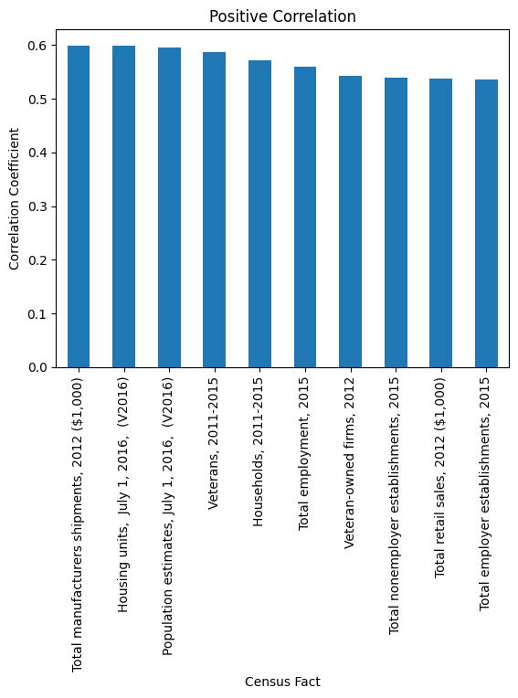

```python
# Combined the different correlation series into a single series
combined_corr = pd.concat([corr16, corr15, corr12, corr10], axis=0)

# Sort the series in descending order and drop the totals rows
combined_corr = combined_corr.sort_values(ascending=False)
combined_corr = combined_corr.drop('totals')

# Create a box plot of the first 10 rows of the correlation series
combined_corr.head(10).plot(xlabel='Census Fact', ylabel='Correlation Coefficient', kind='bar', title='Positive Correlation')
```

> Combined the different correlation values into a single series and sorted them in descending order. Then removed the totals rows from the data and plotted the top ten highest correlation values.

#### Which facts had the greatest correlation with decreased number of firearm background checks?

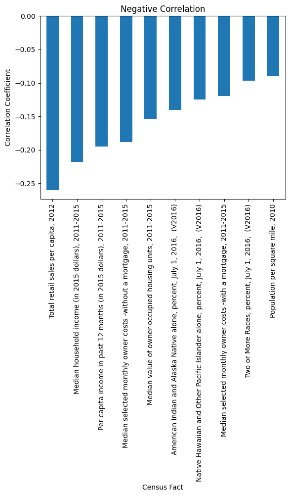

```python
# Plot the first ten correlation values in ascending order
combined_corr.sort_values(ascending=True).head(10).plot(xlabel='Census Fact', ylabel='Correlation Coefficient', kind='bar', title='Negative Correlation')
```

> Sorted the correlation values from smallest to largest and then plotted the first ten values to view the facts that had the greatest negative correlation with firearm background checks.

#### Are the numer of background checks increasing or decreasing each year?

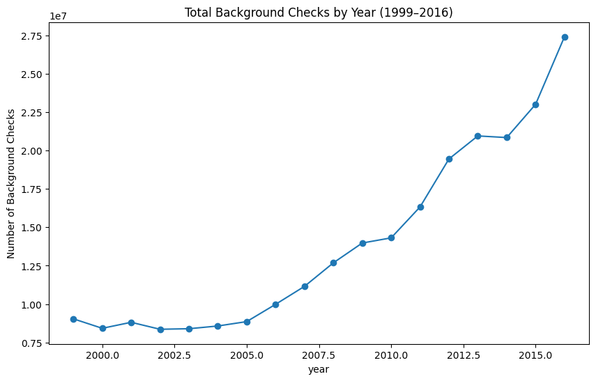

```python
# Group gun data by year and sum totals
yearly_gun_df = gun_df.groupby('year')['totals'].sum()

# Convert the year to integers
yearly_gun_df.index = yearly_gun_df.index.astype(int)

# Filter by year range
yearly_gun_df = yearly_gun_df[(yearly_gun_df.index >= 1999) & (yearly_gun_df.index <= 2016)]

# Plot
yearly_gun_df.plot(kind='line', marker='o', ylabel='Number of Background Checks', title='Total Background Checks by Year (1999–2016)', figsize=(10, 6))
```

> This plot shows the overall trend of the number of background checks

#### Are there any states that are underrepresented in the data?

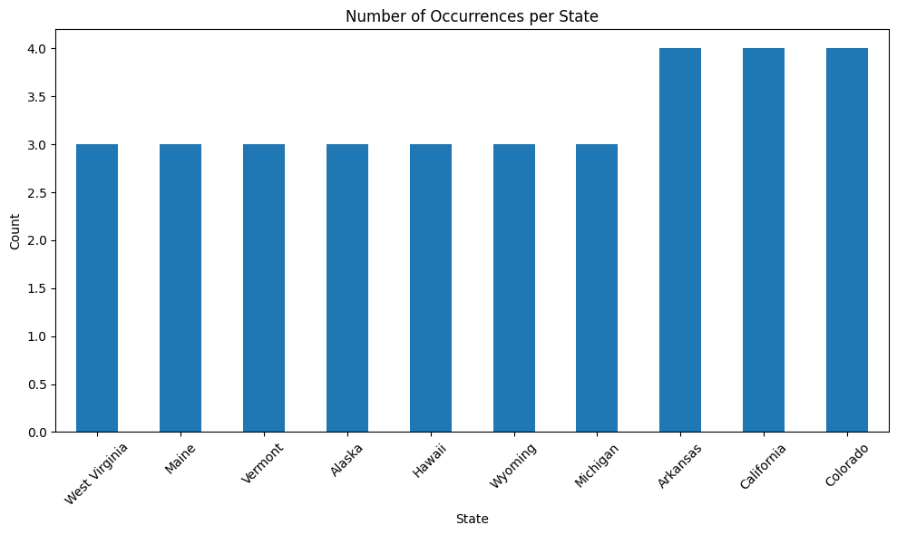

```python
# Combine the data into a single dataframe
combined_df = pd.concat([df['state'] for df in [combined16_df, combined15_df, combined12_df, combined10_df]])

# Count occurrences of each state
state_counts = combined_df.value_counts().sort_values(ascending=True)

# Plot the bar chart for count per state
plt.figure(figsize=(10, 6))
state_counts.head(10).plot(kind='bar')
plt.title('Number of Occurrences per State')
plt.xlabel('State')
plt.ylabel('Count')
plt.xticks(rotation=45)
plt.tight_layout()
plt.show()
```

> Checked the number of instance each state appears in the data.

## Conclusions

```python
# Running this cell will execute a bash command to convert this notebook to an .html file
!python -m nbconvert --to html Investigate_a_Dataset.ipynb
```

```
[NbConvertApp] Converting notebook Investigate_a_Dataset.ipynb to html
[NbConvertApp] WARNING | Alternative text is missing on 4 image(s).
[NbConvertApp] Writing 610788 bytes to Investigate_a_Dataset.html
```